# Machine Learning

**Group Members:** (1.) Jian Hao Chiah (2.) Yunus Emre Bozkurt (3.) Nashita Behroz Jalil

## Recidivism

Recidivism – the tendency for an individual who has previously committed a crime to commit another crime in the future. One key input to a judge’s sentencing decision is how likely a given convict is to re-offend, or recidivate.

We will be following a Pro Publica article that analyzes the output of COMPAS. The article is [here](https://www.propublica.org/article/machine-bias-risk-assessments-in-criminal-sentencing). Is not necessary to read it for this question.

## Data

The code below downloads the data used in the pro republica article.

```r
raw <- read_csv("https://raw.githubusercontent.com/propublica/compas-analysis/master/compas-scores-two-years.csv")
```

```
## ──────────────────────────────────────────────────────── Delimiter: "," chr
## (19): name, first, last, sex, age_cat, race, c_case_number, c_charge_de... dbl
## (19): id, age, juv_fel_count, decile_score...12, juv_misd_count, juv_ot... lgl
## (1): violent_recid dttm (2): c_jail_in, c_jail_out date (12):
## compas_screening_date, dob, c_offense_date, c_arrest_date, r_offe...
```

Minor cleaning:

```r
## Main working data
df <- raw %>%
        filter(days_b_screening_arrest <= 30) %>%
        filter(days_b_screening_arrest >= -30) %>%
        filter(is_recid != -1) %>%
        filter(c_charge_degree != "O") %>%
        filter(score_text != 'N/A') %>%
  rename(priors_count = `priors_count...15`,
        decile_score =  `decile_score...12` )

## clean main working data a bit more
df <- df %>%
  mutate(length_of_stay = as.numeric(as.Date(df$c_jail_out) - as.Date(df$c_jail_in)),
         charge_factor = fct_explicit_na(c_charge_desc),
         race_factor = fct_explicit_na(race),
         race_factor = fct_relevel(race_factor, "Caucasian"),
         charge_factor = fct_lump_min(charge_factor, 30),
         sex_factor = factor(sex, levels = c("Female","Male")),
         priors_factor = ifelse(priors_count > 20, 20, priors_count),
         priors_factor = factor(priors_factor),
         two_year_recid = factor(two_year_recid)) %>%
  select(two_year_recid, age, sex_factor , juv_fel_count , juv_misd_count , juv_other_count , priors_count , c_charge_degree , charge_factor, race_factor, decile_score, length_of_stay)
feature_names <- names(df)[-c(1,10,11)]
```

## Recidivism Risk

In the data, the variable `decile_score` is the COMPAS score actually used to evaluate a defendant’s risk of recidivism. Each individual in the data set was assigned a `decile_score` ranging from 1 to 10. This score represents the perceived risk of recidivism with 1 being the lowest risk and 10 being the highest. This score is produced from a criminal risk assessment algorithm.

> Risk assessment tools are designed to do one thing: take in the details of a defendant’s profile and spit out a recidivism score –a single number estimating the likelihood that he or she will reoffend. A judge then factors that score into a myriad of decisions that can determine what type of rehabilitation services particular defendants should receive, whether they should be held in jail before trial, and how severe their sentences should be. A low score paves the way for a kinder fate. A high score does precisely the opposite. [excerpt taken from this article](https://www.technologyreview.com/2019/01/21/137783/algorithms-criminal-justice-ai/)

The outcome variable in the data set is `two_year_recid`. It is binary and equal to one if the individual had been jailed for a new crime in next two years from the original release date.

## Part I: Data visualization

In a subset of the data focusing only on Caucasians and African-Americans (from `race_factor`), we construct:

1. A bar chart showing the incidence of each `decile_score` by `race_factor`, with one panel for men and one for women.
2. A figure that shows the actual recidivism rate vs `decile_score` by `race_factor`, with one panel for men and one for women.

```r
dfI <- df %>%
  select(two_year_recid, sex_factor, race_factor, decile_score) %>%
  filter(race_factor %in% c("Caucasian","African-American")) %>%
  mutate(two_year_recid = as.numeric(as.character(two_year_recid)))
```

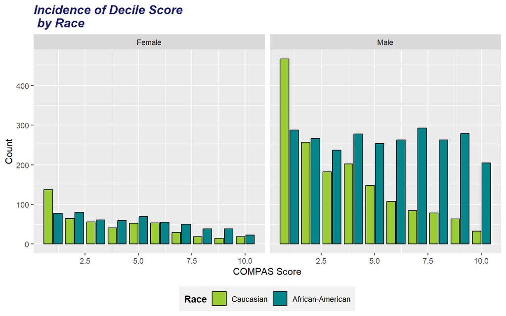

```r
###code here
#Graph 1 --- bar chart
g1 <- ggplot(dfI,
       aes(x = decile_score,
           fill = race_factor),
       colour = race_factor,
       line_type = race_factor) +
  labs(title = "Incidence of Decile Score \n by Race",
       x = "COMPAS Score",
       y = "Count",
       fill = "Race") +
  geom_bar(position = 'dodge2', colour = 'black') +
  #use geom_bar instead of geom_col as incidence refers to counting of number of cases at each x position

  facet_wrap(~sex_factor)

g1 + scale_fill_manual(values = c("yellowgreen", "turquoise4")) + theme(plot.title = element_text(color="midnightblue", size=14, face="bold.italic"),legend.title = element_text(face = "bold"),legend.background = element_rect(fill="gray95", size=.5), legend.position = "bottom")
```

**Note :** a. For Caucasian people (both male and female) there is a decreasing trend in number as the decile score increases, which is not the case for African-American people, their numbers seems to be constant throughout the COMPAS score

**Note :** b. After the COMPAS score 2.5 the scores of African-American people are higher than the Caucasians

**Note :** c. For males, the difference between the Caucasians and African-American people gets bigger as the COMPAS score increases (After approx. score - 3)

**Note :** d. Generally the count is higher for males than the females

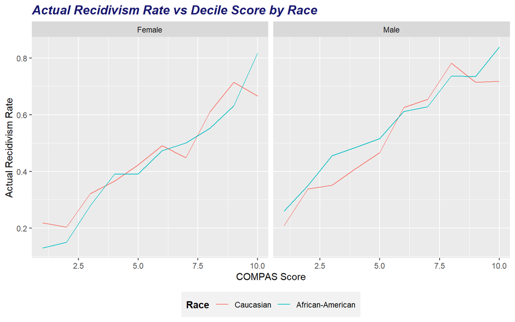

```r
#Graph 2 --- figure
fig <- dfI %>%
  group_by(sex_factor, race_factor, decile_score) %>%
  summarise(recid_rate = weighted.mean(two_year_recid, na.rm = T),
            n = n())
g2 <- ggplot(fig,
       aes(x = decile_score,
           y = recid_rate,
           colour = race_factor)) +
  labs(title = "Actual Recidivism Rate vs Decile Score by Race",
       x = "COMPAS Score",
       y = "Actual Recidivism Rate",
       colour = "Race") +
  geom_line() +
  facet_wrap(~sex_factor)



g2 + theme(plot.title = element_text(color="midnightblue", size=14, face="bold.italic"), legend.title = element_text(face = "bold"), legend.background = element_rect(fill="gray95", size=.5), legend.position = "bottom")
```

## Part II: Constructing our own risk score

We constructed our own risk scores by first predicting the probability that an individual reoffends within two years given their observable characteristics in the data. In constructing this risk score, we have as potential features the following: age, sex_factor, juv_fel_count, juv_misd_count, juv_other_count, priors_count, c_charge_degree, charge_factor, length_of_stay.

That is, our predictions shouldn’t use the COMPAS `decile_score` nor `race_factor`. We do not use race in making our predictions, since this is a protected category – the idea being that a persons’ risk score should be independent of race.

Our risk scores will be constructed as follows (1) predict the probability of `two_year_recid` given available features, and (2) turn our predicted probabilities into a decile score to compare with COMPAS. In making predictions, we will attempt to maximize the model accuracy, which is obviously not the only measure we could use, but seems like a good place to start.

### Data splitting

Split data into training and test set. Remember to set the seed for reproducibility.

```r
# data splitting here
dfII <- df %>%
  select(-race_factor,
         -decile_score)

#sample split
set.seed(1996)

df_splits <- initial_split(dfII, prop = 3/4)
# training and testing data
train <- training(df_splits)
test <- testing(df_splits)
```

### Logit

```r
## Logit here
rec_base <- recipe(
  two_year_recid ~ .,
  data = train
  ) %>%
  step_dummy(all_nominal(), -two_year_recid) %>% #nominal
  step_normalize(all_predictors()) %>% #created dummy and normalized it
  step_nzv(all_predictors()) #removes ones with little variation

# Examine object - juice / bake
base_dta <- rec_base %>% prep() %>% juice()  #Just to view

# Step 2: Model
mod_glm <- logistic_reg() %>%
  set_engine('glm')

# Step 3: Workflow
wf_base <- workflow() %>%
  add_recipe(rec_base) %>%
  add_model(mod_glm)  #adding part 1 and 2

# Step 4: Fit
fit_base <- wf_base %>% fit(data = train)    #without the workflow it will show all the steps (u can check by removing it)
#R suggested a swap from extract_fit_parsnip() to extract_fit_parsnip()

testB <- test %>%
  select(two_year_recid) %>%
  bind_cols(predict(fit_base, new_data = test))

testB
```

```
## # A tibble: 1,543 × 2
##    two_year_recid .pred_class
##    <fct>          <fct>
##  1 0              0
##  2 0              0
##  3 0              0
##  4 0              0
##  5 0              0
##  6 1              1
##  7 1              1
##  8 0              0
##  9 0              0
## 10 1              0
## # … with 1,533 more rows
```

```r
#'Full' SPecification
# Step 1:  recipe
rec_full <- recipe(
  two_year_recid ~ .,
  data = train
  ) %>%
  step_dummy(all_nominal(), -two_year_recid) %>%
  step_interact(~ all_predictors() * all_predictors()) %>%
  step_poly(age, degree = 3) %>%
  step_normalize(all_predictors()) %>%
  step_nzv(all_predictors()) #kick out regression with no variation

# Step 2: Workflow
wf_full <- workflow() %>%
  add_recipe(rec_full) %>%
  add_model(mod_glm)

# Step 3: Fit
fit_full <- wf_full %>% fit(data = train)
```

[output not shown]

[output cut: 631 more lines]

[output not shown]

```r
# Obtain predicted probabilities
testF <- test %>%
  select(two_year_recid) %>%
  bind_cols(predict(fit_full, new_data = test))
test
```

```
## # A tibble: 1,543 × 10
##    two_y…¹   age sex_f…² juv_f…³ juv_m…⁴ juv_o…⁵ prior…⁶ c_cha…⁷ charg…⁸ lengt…⁹
##    <fct>   <dbl> <fct>     <dbl>   <dbl>   <dbl>   <dbl> <chr>   <fct>     <dbl>
##  1 0          69 Male          0       0       0       0 F       Other         1
##  2 0          39 Female        0       0       0       0 M       Battery       3
##  3 0          27 Male          0       0       0       0 F       Other         1
##  4 0          41 Male          0       0       0       0 F       Poss3,…       1
##  5 0          37 Male          0       0       0       0 M       Battery       0
##  6 1          31 Male          0       0       0       5 F       Other         1
##  7 1          21 Male          0       0       0       1 F       Batter…       3
##  8 0          32 Male          0       0       0       0 M       Battery       2
##  9 0          21 Female        0       0       0       2 F       arrest…      80
## 10 1          29 Male          0       0       0       2 M       Viol I…       1
## # … with 1,533 more rows, and abbreviated variable names ¹two_year_recid,
## #   ²sex_factor, ³juv_fel_count, ⁴juv_misd_count, ⁵juv_other_count,
## #   ⁶priors_count, ⁷c_charge_degree, ⁸charge_factor, ⁹length_of_stay
```

```r
table(cut_width(runif(5278), 0.1))
```

```
##
## [-0.05,0.05]  (0.05,0.15]  (0.15,0.25]  (0.25,0.35]  (0.35,0.45]  (0.45,0.55]
##          249          506          550          502          534          524
##  (0.55,0.65]  (0.65,0.75]  (0.75,0.85]  (0.85,0.95]  (0.95,1.05]
##          566          497          520          550          280
```

### Penalized regression

We estimate penalized regressions (lasso, ridge, elastic net) of our Logit above. We `tune()` our hyper-parameters based on accuracy.

##Lasso

```r
# penalized regression here
# Lasso
## Split training data into folds
cv_splits <- vfold_cv(train, v = 5, repeats = 1)
```

```r
## Model
lasso_model <- logistic_reg(penalty = tune(), mixture = 1) %>%
  set_engine("glmnet") #tune the penalty parameter - if we know that we can just type it in, here it sets hypothetical value

## Workflow
lasso_wf <- workflow() %>%
  add_model(lasso_model) %>%
  add_recipe(rec_full)
```

```r
#Tuning
lambda_grid <- grid_regular(penalty(), levels = 50)
```

```r
# tune grid
cv_lasso <- tune_grid(
  lasso_wf,
  resamples = cv_splits,
  grid = lambda_grid
  )
```

```
## ! Fold1: preprocessor 1/1: Column(s) have zero variance so scaling cannot be used: `juv_fel_count_x...
```

```
## ! Fold2: preprocessor 1/1: Column(s) have zero variance so scaling cannot be used: `juv_fel_count_x...
```

```
## ! Fold3: preprocessor 1/1: Column(s) have zero variance so scaling cannot be used: `juv_fel_count_x...
```

```
## ! Fold4: preprocessor 1/1: Column(s) have zero variance so scaling cannot be used: `juv_fel_count_x...
```

```
## ! Fold5: preprocessor 1/1: Column(s) have zero variance so scaling cannot be used: `juv_fel_count_x...
```

```r
## Winner
cv_lasso %>%
select_best(cv_lasso, metric = "accuracy")
```

```
## # A tibble: 1 × 2
##    penalty .config
##      <dbl> <chr>
## 1 0.000543 Preprocessor1_Model34
```

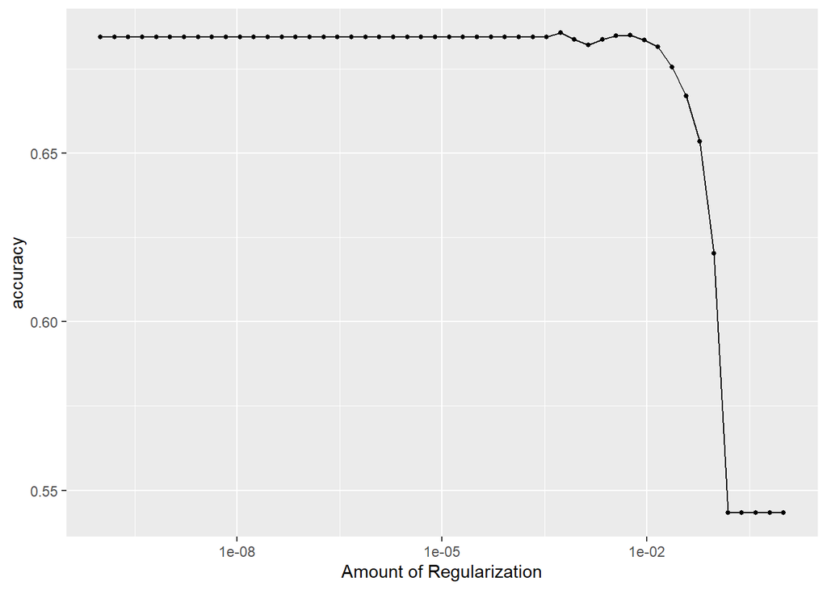

```r
## cv plot
autoplot(cv_lasso, metric = "accuracy")
```

```r
# extract optimal lambda
opt_lambda <- cv_lasso %>%  select_best("accuracy")

## Final fit
fit_lasso <- finalize_workflow(lasso_wf, opt_lambda) %>%
  fit(data = train) %>%
  extract_fit_parsnip() #to replace pull_workflow_fit()
```

[output not shown]

[output cut: 631 more lines]

[output not shown]

```r
# extract optimal lambda
opt_lambda_1se <- cv_lasso %>%
  select_by_one_std_err(desc(penalty), metric = "accuracy", maximize = F) #select the least one, and 1 se lambda (one with bigger lambda will be simpler one)
## Final fit
fit_lasso_1se <- finalize_workflow(lasso_wf, opt_lambda_1se) %>%
  fit(data = train) %>%
  extract_fit_parsnip() #to replace pull_workflow_fit()
```

[output not shown]

[output cut: 631 more lines]

[output not shown]

```r
#Comparing different methods
# evaluation - add predicted values from each model to test data

# first prep our test data

test_baked <- bake(rec_full %>% prep(), new_data = test)
```

[output not shown]

[output cut: 631 more lines]

[output not shown]

```r
test_base  <- bake(rec_base %>% prep(), new_data = test)  #applying recipe to test data set, twice - one for base and another for full
```

```r
model.comp <- test %>%
  select(two_year_recid) %>%
  bind_cols(predict(fit_base, new_data = test_base) %>% rename(base = .pred_class)) %>%
  bind_cols(predict(fit_full, new_data = test_baked) %>% rename(full = .pred_class)) %>%
  bind_cols(predict(fit_lasso, new_data = test_baked) %>% rename(lasso = .pred_class)) %>%
  bind_cols(predict(fit_lasso_1se, new_data = test_baked) %>% rename(lasso_1se = .pred_class))
```

##Ridge Regression

```r
## Model
ridge_model <- logistic_reg(penalty = tune(), mixture = 0) %>% ##added Logit
  set_engine("glmnet")

## Workflow
ridge_wf <- workflow() %>%
  add_model(ridge_model) %>%
  add_recipe(rec_full)
```

```r
lambda_grid <- grid_regular(penalty(), levels = 50)
```

```r
cv_ridge <- tune_grid(
  ridge_wf,
  resamples = cv_splits,
  grid = lambda_grid
  )
```

```
## ! Fold1: preprocessor 1/1: Column(s) have zero variance so scaling cannot be used: `juv_fel_count_x...
```

```
## ! Fold2: preprocessor 1/1: Column(s) have zero variance so scaling cannot be used: `juv_fel_count_x...
```

```
## ! Fold3: preprocessor 1/1: Column(s) have zero variance so scaling cannot be used: `juv_fel_count_x...
```

```
## ! Fold4: preprocessor 1/1: Column(s) have zero variance so scaling cannot be used: `juv_fel_count_x...
```

```
## ! Fold5: preprocessor 1/1: Column(s) have zero variance so scaling cannot be used: `juv_fel_count_x...
```

```r
## Winner
cv_ridge %>%  select_best("accuracy")
```

```
## # A tibble: 1 × 2
##   penalty .config
##     <dbl> <chr>
## 1  0.0373 Preprocessor1_Model43
```

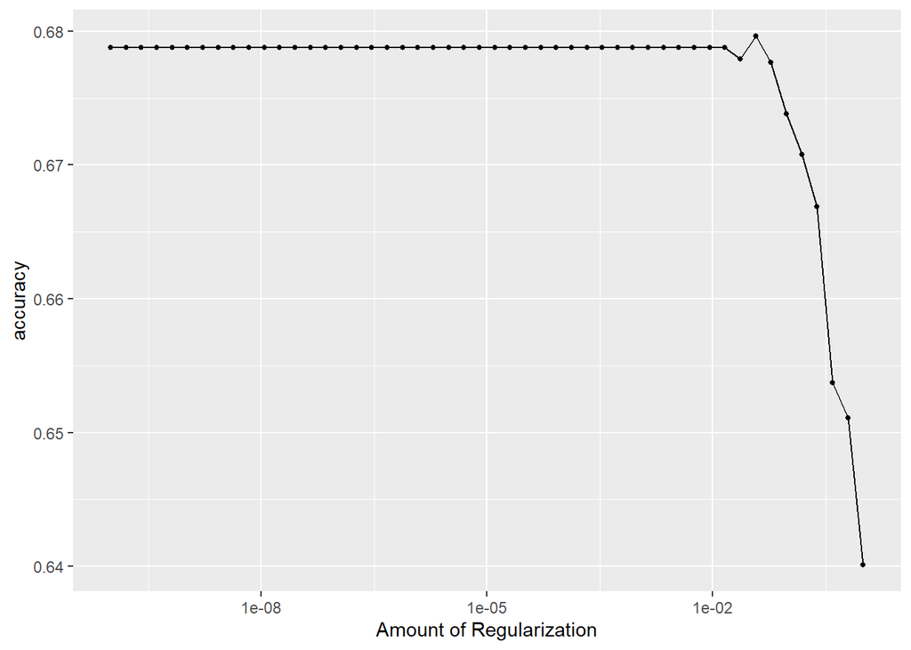

```r
## cv plot
autoplot(cv_ridge, metric = "accuracy")
```

```r
# penalty
opt_ridge <- cv_ridge %>%  select_best("accuracy")

## Final fit
fit_ridge <- finalize_workflow(ridge_wf, opt_ridge) %>% fit( data = train) %>%   extract_fit_parsnip()
```

[output not shown]

[output cut: 631 more lines]

[output not shown]

```r
#model.comp <- model.comp %>%
  #bind_cols(predict(fit_ridge, new_data = test_baked) %>% rename(ridge = .pred))
```

```r
fig_data <- model.comp %>%
  pivot_longer(cols = c('base', 'full','lasso','lasso_1se','post_lasso','ridge'), names_to = "Model")

ggplot(fig_data, aes(y = score, x = value)) +
  geom_point() +
  geom_smooth(method = 'lm', se = F) +
  facet_grid(~Model)

fig_data %>%
  group_by(Model) %>%
  summarise(mse = mean((score - value)^2)) %>%
  arrange(mse)
```

[output not shown]

##Elastic net

```r
EL_model <- logistic_reg(penalty = tune(), mixture = tune()) %>%
  set_engine("glmnet")

## Workflow
EL_wf <- workflow() %>%
  add_model(EL_model) %>%
  add_recipe(rec_full)


# tune grid
cv_EL <- tune_grid(
  EL_wf,
  resamples = cv_splits,
  grid = expand_grid(penalty = 10^seq(-3,1, length = 50), mixture = c(.25, .5, .75))
  )
```

```
## ! Fold1: preprocessor 1/1: Column(s) have zero variance so scaling cannot be used: `juv_fel_count_x...
```

```
## ! Fold2: preprocessor 1/1: Column(s) have zero variance so scaling cannot be used: `juv_fel_count_x...
```

```
## ! Fold3: preprocessor 1/1: Column(s) have zero variance so scaling cannot be used: `juv_fel_count_x...
```

```
## ! Fold4: preprocessor 1/1: Column(s) have zero variance so scaling cannot be used: `juv_fel_count_x...
```

```
## ! Fold5: preprocessor 1/1: Column(s) have zero variance so scaling cannot be used: `juv_fel_count_x...
```

```r
## Winner
cv_EL %>%  select_best("accuracy")
```

```
## # A tibble: 1 × 3
##   penalty mixture .config
##     <dbl>   <dbl> <chr>
## 1  0.0139    0.75 Preprocessor1_Model115
```

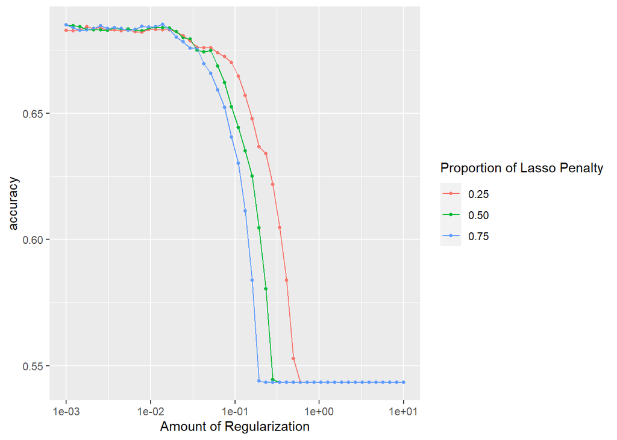

```r
## cv plot
autoplot(cv_EL, metric = "accuracy")
```

```r
# penalty
opt_EL <- cv_EL %>%  select_best("accuracy")

## Final fit
fit_EL <- finalize_workflow(EL_wf, opt_EL) %>% fit( data = train) %>%   extract_fit_parsnip()
```

[output not shown]

[output cut: 631 more lines]

[output not shown]

```r
model.comp <- model.comp %>%
  #bind_cols(predict(fit_EL, new_data = test_baked) %>% rename(EL = .pred))

fig_data <- model.comp %>%
  pivot_longer(cols = -score, names_to = "Model")

ggplot(fig_data, aes(y = score, x = value)) +
  geom_point() +
  geom_smooth(method = 'lm', se = F) +
  facet_grid(~Model)

fig_data %>%
  group_by(Model) %>%
  summarise(mse = mean((score - value)^2)) %>%
  arrange(mse)
```

[output not shown]

### Random Forest

We estimate a random forest regression, with mode set to classification.

```r
# RF here

rec_forest <- recipe(
  two_year_recid ~ ., ntree = 100,
  data = train
)

doParallel::registerDoParallel()

forest_reg <- rand_forest(mtry = tune(),
                          engine = 'ranger',
                          mode = 'classification')

wf_forest <- workflow() %>%
  add_recipe(rec_forest) %>%
  add_model(forest_reg)

cv_forest <- tune_grid(
  wf_forest,
  resamples = cv_splits,
  #grid = grid_regular(mtry(range = c(1,12)),min_n(range = c(2L,15L)), levels = 12) #mtry - random try
  #grid = grid_latin_hypercube(mtry(range = c(1,12)),min_n(range = c(2L,15L)), size = 30)
  grid_max_entropy(mtry(range = c(1,12)),min_n(range = c(2L,15L)), size = 50)
  )
```

```
## i Creating pre-processing data to finalize unknown parameter: mtry
```

```r
cv_forest %>% select_best('accuracy')
```

```
## # A tibble: 1 × 2
##    mtry .config
##   <int> <chr>
## 1     2 Preprocessor1_Model8
```

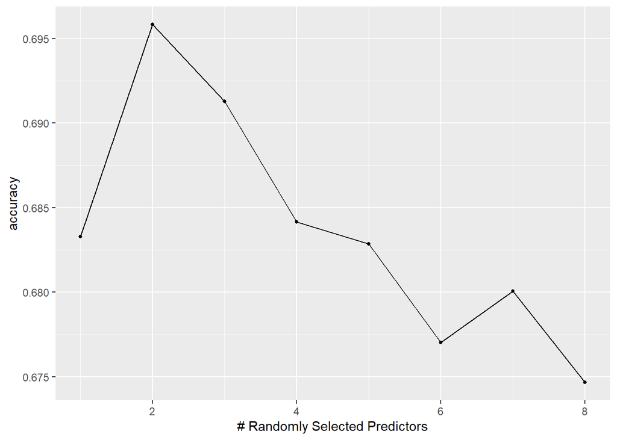

```r
autoplot(cv_forest, metric = 'accuracy')
```

```r
# extract optimal mtry
opt_mtry <- cv_forest %>%  select_best('accuracy')

## Final fit
fit_forest <- finalize_workflow(wf_forest, opt_mtry) %>%
  fit(data = train) %>%
  pull_workflow_fit()
model.comp <- model.comp %>%
  bind_cols(predict(fit_forest, new_data = test) %>% rename(rand_forest = .pred))
```

```r
fig_data <- model.comp %>%
  pivot_longer(cols = -score, names_to = "Model")

ggplot(fig_data, aes(y = score, x = value)) +
  geom_point() +
  geom_smooth(method = 'lm', se = F) +
  facet_grid(~Model)

fig_data %>%
  group_by(Model) %>%
  summarise(mse = mean((score - value)^2)) %>%
  arrange(mse) #random forest is the best
```

[output not shown]

### Predictions

```r
# Add predicted probabilities here.
test_baked <- bake(rec_full %>% prep(), new_data = test, all_predictors())
test_base <- bake (rec_base %>% prep(), new_data = test, all_predictors())

test_results <- test%>%
  select(two_year_recid) %>%
  bind_cols(
    restricted = predict(fit_base, new_data = test_base) %>% rename(Restricted = .pred),
    full = predict(fit_full, new_data = test_baked)%>% rename(Full = .pred),
    predict(fit_EL, new_data =test_baked)%>% rename(EL = .pred),
    predict(fit_ridge, new_data = test_baked)%>% rename(Ridge = .pred),
    predict(fit_lasso, new_data = test_baked) %>% rename(Lasso = .pred)
  )
```

## Algorithm bias

A check to see if the decile risk rankings have unintended bias:

```r
## Code here
set.seed(1996)

#splits
df_splits2 <- initial_split(df, prob = 3/4)

# training and testing data
train2 <- training(df_splits2)
test2 <- testing(df_splits2)


models <- list(
  model1  <- glm(decile_score ~ age+sex_factor+juv_fel_count+juv_misd_count+priors_count+c_charge_degree+juv_other_count+charge_factor+length_of_stay + race_factor, data = test2,family=binomial(link='logit')),

model2  <- glm(lasso_score ~ age+sex_factor+juv_fel_count+juv_misd_count+priors_count+c_charge_degree+juv_other_count+charge_factor+length_of_stay + race_factor, data = test2, family=binomial(link='logit')))


modelsummary(models,
             stars = T,
             gof_omit = '[^R2|Num.Obs]') %>%
  kable_classic_2()
```

[output not shown]

## Post script.

```r
dfII <- df %>%
  select(two_year_recid, sex_factor, race_factor, lasso_score) %>%
  filter(race_factor %in% c("Caucasian","African-American")) %>%
  mutate(two_year_recid = as.numeric(as.character(two_year_recid)))
```

```r
###code here
#Graph 1 --- bar chart
g1_1 <- ggplot(dfII,
       aes(x = lasso_score,
           fill = race_factor),
       colour = race_factor,
       line_type = race_factor) +
  labs(title = "Incidence of Decile Score \n by Race",
       x = "COMPAS Score",
       y = "Count",
       fill = "Race") +
  geom_bar(position = 'dodge2', colour = 'black') +
  #use geom_bar instead of geom_col as incidence refers to counting of number of cases at each x position

  facet_wrap(~sex_factor)

g1_1 + scale_fill_manual(values = c("yellowgreen", "turquoise4")) + theme(plot.title = element_text(color="midnightblue", size=14, face="bold.italic"),legend.title = element_text(face = "bold"),legend.background = element_rect(fill="gray95", size=.5), legend.position = "bottom")
```

[output not shown]

```r
#Graph 2 --- figure
fig_1 <- dfII %>%
  group_by(sex_factor, race_factor, lasso_score) %>%
  summarise(recid_rate = weighted.mean(two_year_recid, na.rm = T),
            n = n())
```

```r
g2_1 <- ggplot(fig_1,
       aes(x = lasso_score,
           y = recid_rate,
           colour = race_factor)) +
  labs(title = "Actual Recidivism Rate vs Decile Score by Race",
       x = "COMPAS Score",
       y = "Actual Recidivism Rate",
       colour = "Race") +
  geom_line() +
  facet_wrap(~sex_factor)



g2_1 + theme(plot.title = element_text(color="midnightblue", size=14, face="bold.italic"), legend.title = element_text(face = "bold"), legend.background = element_rect(fill="gray95", size=.5), legend.position = "bottom")
```

[output not shown]